# Cyclistic Bike-Share Analysis

BJ Herrera

2022-08-07

# Background of the problem

This case study is done as part of the [Google Data Analytics Professional Certificate](https://www.coursera.org/professional-certificates/google-data-analytics) in [Coursera](https://www.coursera.org). In this case study (or capstone project), the task is to help a fictional company, Cyclistic, make a key business decision. Specifically, the company launched a bike-sharing offering in 2016, where they offer a variety of options to riders, including single-day passes, full-day passes and annual memberships to all their bikes. Since launch, the company noticed that annual memberships account for the most profits. Thus, the company wants to maximize annual memberships. To do this, the company will come up with design marketing strategies aimed at converting causal riders (those who opt for single-day passes or full-day passes) into annual members. The purpose of this analysis is to help understand how casual riders and annual members use Cyclistic bikes differently.

**Business task: Understand how casual riders and annual members use Cyclistic bikes differently in order to convert casual riders into annual members and maximize the number of annual memberships.**

# The Data

Although the company in this case study is fictional, the data comes from [Lyft Bikes and Scooters, LLC](https://www.lyft.com), a real company that offers bike-sharing options to its users. The data can be downloaded [here](https://divvy-tripdata.s3.amazonaws.com/index.html). For this case study, we will limit ourselves to data from the last 12 months. As of August 7, 2022, the latest data is for July 2022. Thus, the data included in this analysis will be from August 2021 to July 2022. The code chunk below loads the R libraries and data to be used in this analysis.

```r
library(tidyverse)
library(lubridate)
library(skimr)
options(dplyr.summarise.inform = FALSE)

filenames <- list.files(path="./data", pattern=".csv", all.files=TRUE, full.names=TRUE)

bike_data <- read_csv(filenames[1])
for (filename in filenames[2:12]) {
  bike_data <- rbind(bike_data, read_csv(filename))
}

min_date <- date(min(bike_data$started_at))
max_date <- date(max(bike_data$ended_at))
```

# Data Cleaning

We begin the analysis by cleaning the dataset for any invalid data. To get a better understanding of the data, we first skim through the entire data using the `skim_without_charts` function.

```r
skim_without_charts(bike_data)
```

Data summary

| Name | bike_data |
| --- | --- |
| Number of rows | 5901463 |
| Number of columns | 13 |
| _______________________ |  |
| Column type frequency: |  |
| character | 7 |
| numeric | 4 |
| POSIXct | 2 |
| ________________________ |  |
| Group variables | None |

**Variable type: character**

| skim_variable | n_missing | complete_rate | min | max | empty | n_unique | whitespace |
| --- | --- | --- | --- | --- | --- | --- | --- |
| ride_id | 0 | 1.00 | 16 | 16 | 0 | 5901463 | 0 |
| rideable_type | 0 | 1.00 | 11 | 13 | 0 | 3 | 0 |
| start_station_name | 860786 | 0.85 | 3 | 64 | 0 | 1381 | 0 |
| start_station_id | 860784 | 0.85 | 3 | 44 | 0 | 1226 | 0 |
| end_station_name | 919896 | 0.84 | 9 | 64 | 0 | 1396 | 0 |
| end_station_id | 919896 | 0.84 | 3 | 44 | 0 | 1236 | 0 |
| member_casual | 0 | 1.00 | 6 | 6 | 0 | 2 | 0 |

**Variable type: numeric**

| skim_variable | n_missing | complete_rate | mean | sd | p0 | p25 | p50 | p75 | p100 |
| --- | --- | --- | --- | --- | --- | --- | --- | --- | --- |
| start_lat | 0 | 1 | 41.90 | 0.05 | 41.64 | 41.88 | 41.90 | 41.93 | 45.64 |
| start_lng | 0 | 1 | -87.65 | 0.03 | -87.84 | -87.66 | -87.64 | -87.63 | -73.80 |
| end_lat | 5590 | 1 | 41.90 | 0.05 | 41.39 | 41.88 | 41.90 | 41.93 | 42.37 |
| end_lng | 5590 | 1 | -87.65 | 0.03 | -88.97 | -87.66 | -87.64 | -87.63 | -87.50 |

**Variable type: POSIXct**

| skim_variable | n_missing | complete_rate | min | max | median | n_unique |
| --- | --- | --- | --- | --- | --- | --- |
| started_at | 0 | 1 | 2021-08-01 00:00:04 | 2022-07-31 23:59:58 | 2022-02-14 14:10:08 | 4923992 |
| ended_at | 0 | 1 | 2021-08-01 00:03:11 | 2022-08-04 13:53:01 | 2022-02-14 14:20:23 | 4928247 |

We see that there are many missing data, mostly pertaining to the information to the start and end stations. To address this issue, I would normally ask a supervisor about whether we have the information to fill in the missing data. However, as this is just a case study, I will base my insights only on the available data. Luckily for us, the data used in this analysis is mostly valid. However, there are some invalid records, such as when the data in `ended_at` is earlier than `started_at`. So, we will remove these invalid data.

```r
bike_data <- filter(bike_data, ended_at > started_at)
```

We will also drop the columns we will not be using in this analysis. **Note: This step is only done to speed up computation time by dropping the columns I have not used in this analysis.**

```r
bike_data <- select(bike_data, member_casual, rideable_type, started_at,
                    ended_at)
```

# Exploratory Data Analysis

Before we begin, we will look at the distribution of members and casual riders to determine which group is larger and by how much.

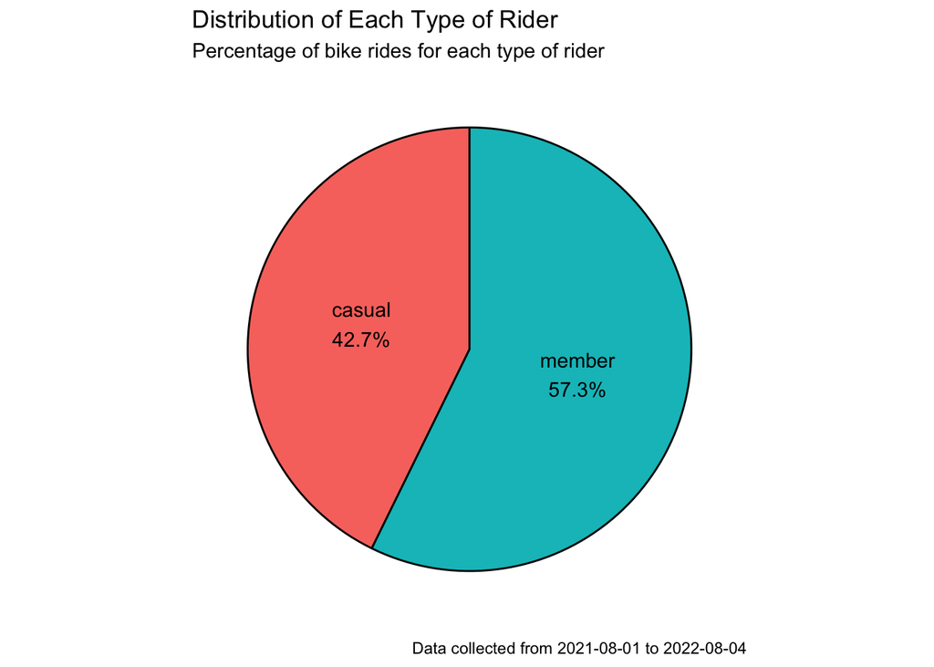

```r
member_counts <- bike_data %>%
  group_by(member_casual) %>%
  summarize(count = n())

total_members <- sum(member_counts$count) # or nrow(bike_data)

ggplot(member_counts, aes("", count, fill = member_casual)) +
  geom_bar(stat = "identity", color = "black") +
  geom_text(aes(label = paste0(member_casual, "\n",
                               round(count / total_members * 100, 1), "%")),
            position = position_stack(vjust=0.5)) +
  coord_polar(theta = "y") +
  labs(title = "Distribution of Each Type of Rider",
       subtitle = "Percentage of bike rides for each type of rider",
       fill = "Type of rider",
       caption = paste0("Data collected from ", min_date, " to ", max_date)) +
  theme_classic() +
  theme(axis.line = element_blank(),
        axis.text = element_blank(),
        axis.ticks = element_blank(),
        axis.title.x = element_blank(),
        axis.title.y = element_blank(),
        legend.position = "none")
```

We clearly see that annual members account for 57.3% of the total number of bikes rides, 14.6% more than what casual riders contribute.

## Cateogies of bikes

We will now look into the different types of bikes available and the preferences of the two groups of riders. We begin by preparing the necessary data.

```r
bike_type_data <- bike_data %>%
  group_by(member_casual, rideable_type) %>%
  summarize(num_rides = n()) %>%
  mutate(rideable_type = str_to_title(gsub("_", " ", rideable_type)))

print(bike_type_data)
```

```
## # A tibble: 5 × 3
## # Groups:   member_casual [2]
##   member_casual rideable_type num_rides
##   <chr>         <chr>             <int>
## 1 casual        Classic Bike    1132794
## 2 casual        Docked Bike      226717
## 3 casual        Electric Bike   1162378
## 4 member        Classic Bike    1922623
## 5 member        Electric Bike   1456315
```

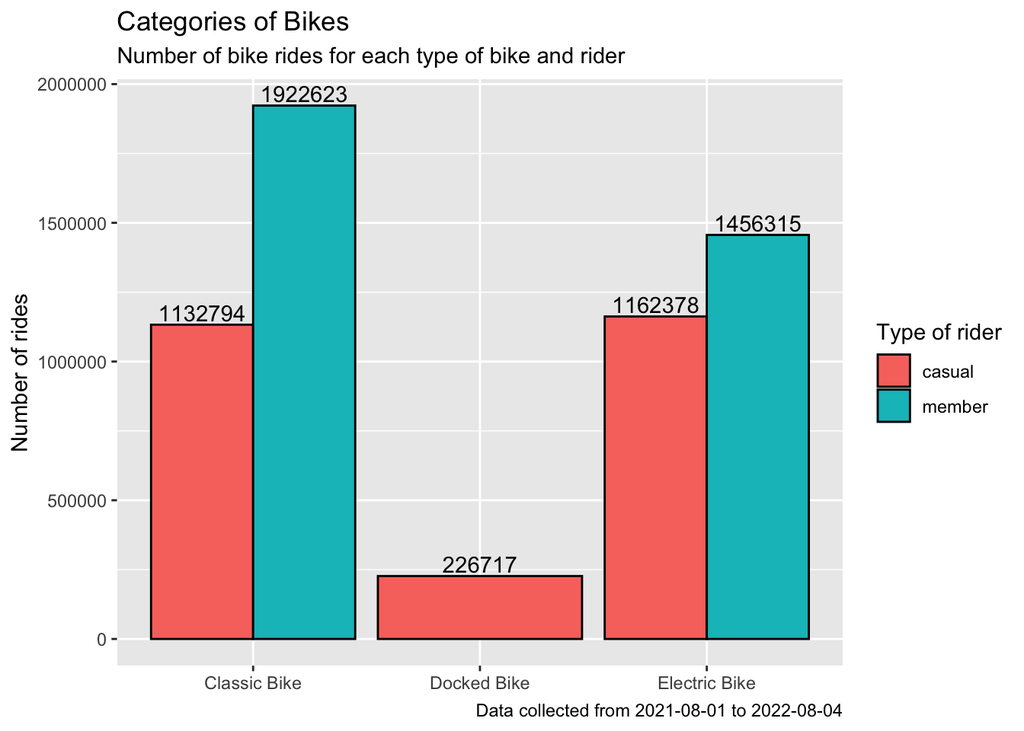

```r
ggplot(bike_type_data, aes(rideable_type, num_rides, fill = member_casual)) +
  geom_bar(position = "dodge", color = "black", stat = "identity") +
  geom_text(aes(label = num_rides), vjust = -0.25,
            position = position_dodge(width = 0.9)) +
  labs(title = "Categories of Bikes",
       subtitle = "Number of bike rides for each type of bike and rider",
       caption = paste0("Data collected from ", min_date, " to ", max_date),
       y = "Number of rides",
       fill = "Type of rider") +
  theme(axis.title.x = element_blank())
```

**Insight: Only casual members use docked bikes.** Although docked bikes contribute the least to the total number of bike rides, we see that only casual riders have used the docked bike over the past 12 months.

## Preferred Day of the Week

```r
week_data <- bike_data %>%
  mutate(day = wday(started_at, label = TRUE)) %>%
  group_by(member_casual, day) %>%
  summarize(num_rides = n())

print(week_data)
```

```
## # A tibble: 14 × 3
## # Groups:   member_casual [2]
##    member_casual day   num_rides
##    <chr>         <ord>     <int>
##  1 casual        Sun      475539
##  2 casual        Mon      299626
##  3 casual        Tue      273782
##  4 casual        Wed      281757
##  5 casual        Thu      316087
##  6 casual        Fri      347599
##  7 casual        Sat      527499
##  8 member        Sun      417918
##  9 member        Mon      472359
## 10 member        Tue      523347
## 11 member        Wed      522582
## 12 member        Thu      522627
## 13 member        Fri      466647
## 14 member        Sat      453458
```

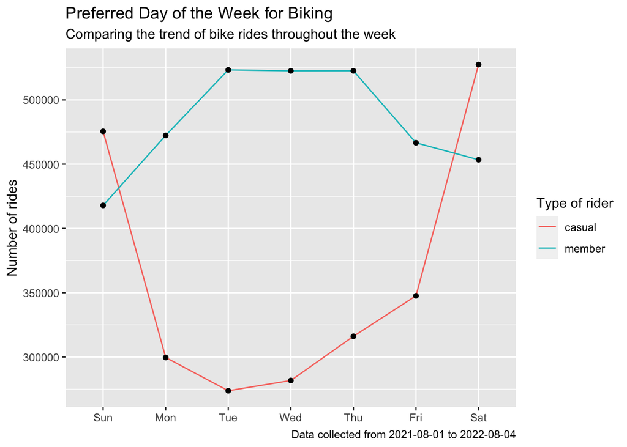

```r
ggplot(week_data, aes(day, num_rides, group = member_casual)) +
  geom_line(aes(color = member_casual)) +
  geom_point() +
  labs(title = "Preferred Day of the Week for Biking",
       subtitle =  "Comparing the trend of bike rides throughout the week",
       caption = paste0("Data collected from ", min_date, " to ", max_date),
       y = "Number of rides",
       color = "Type of rider") +
  theme(axis.title.x = element_blank())
```

**Insight: Casual riders prefer riding on weekends, whereas members prefer weekdays.** We see opposite trends for both casual riders and annual members in terms of the total number of rides throughout the week. Furthermore, we see a spike in the number of rides for casual riders during the weekend, whereas the number of annual members decrease.

## Trip Durations

Now let’s look at how the two types of riders differ in terms of trip duration.

```r
trip_data <- bike_data %>%
  mutate(trip_duration = as.integer(difftime(bike_data$ended_at,
                                             bike_data$started_at,
                                             units = "mins"))) %>%
  group_by(member_casual) %>%
  summarize(avg_trip_duration = mean(trip_duration),
            total_drip_duration = sum(trip_duration),
            max_trip_duration = max(trip_duration),
            min_trip_duration = min(trip_duration))

print(trip_data)
```

```
## # A tibble: 2 × 5
##   member_casual avg_trip_duration total_drip_duration max_trip_duration min_tr…¹
##   <chr>                     <dbl>               <int>             <int>    <int>
## 1 casual                     28.7            72445078             41629        0
## 2 member                     12.4            42048626              1559        0
## # … with abbreviated variable name ¹min_trip_duration
```

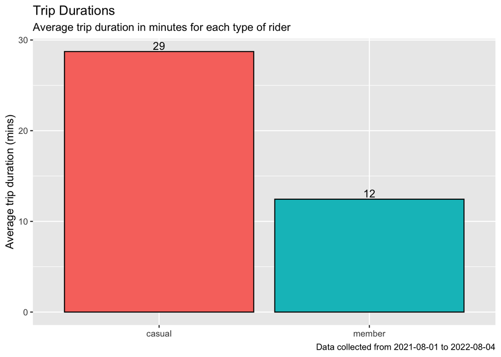

```r
ggplot(trip_data, aes(member_casual, avg_trip_duration, fill=member_casual)) +
  geom_bar(color = "black", stat = "identity") +
  geom_text(aes(label = round(avg_trip_duration)), vjust = -0.25) +
  labs(title = "Trip Durations",
       subtitle = "Average trip duration in minutes for each type of rider",
       caption = paste0("Data collected from ", min_date, " to ", max_date),
       y = "Average trip duration (mins)") +
  theme(axis.title.x = element_blank(),
        legend.position = "none")
```

**Insight: Casual riders tend to use the bikes for longer durations than members do.** Based on our analysis, the average trip duration for casual riders is over two times more than the average trip duration for members.

# Conclusion and Recommendations

The analysis included in this report shows how casual riders differ from annual members. Specifically, the three main insights drawn from this analysis are:

- Only casual members use docked bikes
- Casual riders prefer riding on weekends, whereas members prefer weekdays
- Casual riders tend to use the bikes for longer durations than members do

These key insights can help the Cyclistic marketing team come up with a targeted marketing strategy that can effectively reach out to casual riders and hopefully convince them to sign up for an annual membership.

Because of hardware limitations and resources needed to perform some of the more complex analysis, I have outlined some recommendations for future analysis:

- Compare the preferred start and end locations for both casual riders and annual members, and generate a geographical plot showing where these places are in the map
- Compare the average distance traveled for both casual riders and annual members (you can use the Haversine formula for simplicity or a more accurate algorithm that considers the shortest path between two points in a map)